- Diego Arturo Padilla Domínguez
- A01552594

# Business case: Understanding profitability in the US financial market

**Descripción del caso**

Te han contratado como científico de datos en una importante empresa de fondos de inversión en el departamento de análisis financiero. La empresa lleva varios años realizando análisis y previsiones financieras. Te han contratado para idear enfoques alternativos para realizar análisis descriptivos con el fin de encontrar mejores alternativas futuras para los métodos de previsión. Para poder llevar esto a cabo se tendra que llevar a cabo un análisis de los estados financieros trimestrales de toda la historia de las empresas públicas estadounidendes que cotizan denntro de la bolsa de Nueva York y en el NASDAQ.

Cargar datos desde google drive

**Nota: no es necesario si se tiene el repositorio local**

```python
from google.colab import drive

drive.mount("/content/gdrive")
```

```python
%cd "/content/gdrive/MyDrive/IA/Estadistica"
%ls
```

```
/content/gdrive/MyDrive/IA/Estadistica
bcase.ipynb  Datos.csv  Firmas.csv
```

IMPORTAR LIBRERIAS

```python
import pandas as pd
import numpy as np
import seaborn as sns
```

Importar set de datos

```python
df_firms = pd.read_csv('Firmas.csv')
df_data = pd.read_csv('Datos.csv')
```

```python
df_firms.head()
```

|  | Ticker | Name | N | Class | Country\nof Origin | Type of Asset | Sector NAICS\nlevel 1 | Exchange / Src | Sector\nEconomatica | Sector NAICS\nlast available | partind |
| --- | --- | --- | --- | --- | --- | --- | --- | --- | --- | --- | --- |
| 0 | FLWS | 1 800 Flowers Com Inc | 1 | Com A | US | Stock | Retail Trade | NASDAQ | Trade | Retail Trade | - |
| 1 | TXG | 10x Genomics, Inc | 2 | Com A | US | Stock | Manufacturing | NASDAQ | Electric Electron | Navigational, Measuring, Electromedical, and C... | - |
| 2 | GOED | 1847 Goedeker Inc | 3 | Com | US | Stock | Retail Trade | AMEX | Trade | Furniture and Home Furnishings Stores | - |
| 3 | ONEM | 1life Healthcare, Inc | 4 | Com | US | Stock | Health Care and Social Assistance | NASDAQ | Other | Offices of Physicians | - |
| 4 | SRCE | 1st Source Corp | 5 | Com | US | Stock | Finance and Insurance | NASDAQ | Finance and Insurance | Depository Credit Intermediation | - |

```python
df_data.head()
```

|  | firm | q | revenue | cogs | sgae | otheropexp | extraincome | finexp | incometax | totalassets | totalliabilities | shortdebt | longdebt | stockholderequity | adjprice | originalprice | sharesoutstanding | fiscalmonth | year | cto |
| --- | --- | --- | --- | --- | --- | --- | --- | --- | --- | --- | --- | --- | --- | --- | --- | --- | --- | --- | --- | --- |
| 0 | A | 2000q1 | NaN | NaN | NaN | NaN | NaN | NaN | NaN | NaN | NaN | NaN | NaN | NaN | 63.761670 | 104.0000 | 452000.000 | NaN | 2000 | 1 |
| 1 | A | 2000q2 | 2485000.0 | 1261000.0 | 1010000.0 | 0.0 | 42000.0 | 0.0 | 90000.0 | 7321000.0 | 2679000.0 | 512000.0 | 0.0 | 4642000.0 | 45.215607 | 73.7500 | 452271.967 | 6.0 | 2000 | 2 |
| 2 | A | 2000q3 | 2670000.0 | 1369000.0 | 1091000.0 | 0.0 | 28000.0 | 0.0 | 83000.0 | 7827000.0 | 2925000.0 | 528000.0 | 0.0 | 4902000.0 | 30.003238 | 48.9375 | 453014.579 | 9.0 | 2000 | 3 |
| 3 | A | 2000q4 | 3372000.0 | 1732000.0 | 1182000.0 | 0.0 | 10000.0 | 0.0 | 163000.0 | 8425000.0 | 3160000.0 | 830000.0 | 0.0 | 5265000.0 | 33.566841 | 54.7500 | 456366.381 | 12.0 | 2000 | 4 |
| 4 | A | 2001q1 | 2841000.0 | 1449000.0 | 1113000.0 | 0.0 | -6000.0 | 0.0 | 119000.0 | 9208000.0 | 3667000.0 | 556000.0 | 0.0 | 5541000.0 | 18.840347 | 30.7300 | 456769.737 | 3.0 | 2001 | 1 |

CAMBIAR NOMBRE DE COLUMNAS

```python
df_firms.columns = df_firms.columns.str.replace('Ticker', 'firm')
```

COMBINAR AMBOS DATASETS

```python
df_mrg = pd.merge(df_firms, df_data, on="firm")
df_mrg
```

|  | firm | Name | N | Class | Country\nof Origin | Type of Asset | Sector NAICS\nlevel 1 | Exchange / Src | Sector\nEconomatica | Sector NAICS\nlast available | ... | totalliabilities | shortdebt | longdebt | stockholderequity | adjprice | originalprice | sharesoutstanding | fiscalmonth | year | cto |
| --- | --- | --- | --- | --- | --- | --- | --- | --- | --- | --- | --- | --- | --- | --- | --- | --- | --- | --- | --- | --- | --- |
| 0 | FLWS | 1 800 Flowers Com Inc | 1 | Com A | US | Stock | Retail Trade | NASDAQ | Trade | Retail Trade | ... | 76657.0 | 4380.0 | 8869.0 | 171804.0 | 7.125000 | 7.125000 | 64097.913 | 9.0 | 2000 | 1 |
| 1 | FLWS | 1 800 Flowers Com Inc | 1 | Com A | US | Stock | Retail Trade | NASDAQ | Trade | Retail Trade | ... | 65723.0 | 1839.0 | 9441.0 | 158918.0 | 5.125000 | 5.125000 | 64170.913 | 12.0 | 2000 | 2 |
| 2 | FLWS | 1 800 Flowers Com Inc | 1 | Com A | US | Stock | Retail Trade | NASDAQ | Trade | Retail Trade | ... | 75163.0 | 7654.0 | 10916.0 | 136286.0 | 4.984375 | 4.984375 | 64185.913 | 3.0 | 2000 | 3 |
| 3 | FLWS | 1 800 Flowers Com Inc | 1 | Com A | US | Stock | Retail Trade | NASDAQ | Trade | Retail Trade | ... | 88231.0 | 2157.0 | 10452.0 | 125752.0 | 4.125000 | 4.125000 | 64187.163 | 6.0 | 2000 | 4 |
| 4 | FLWS | 1 800 Flowers Com Inc | 1 | Com A | US | Stock | Retail Trade | NASDAQ | Trade | Retail Trade | ... | 83160.0 | 4777.0 | 12318.0 | 117240.0 | 8.000000 | 8.000000 | 64187.163 | 9.0 | 2001 | 1 |
| ... | ... | ... | ... | ... | ... | ... | ... | ... | ... | ... | ... | ... | ... | ... | ... | ... | ... | ... | ... | ... | ... |
| 323811 | ZNGA | Zynga Inc | 3608 | Com A | US | Stock | Information | NASDAQ | Software & Data | Data Processing, Hosting, and Related Services | ... | 3111600.0 | 17700.0 | 1457000.0 | 3020600.0 | 10.630000 | 10.630000 | 1088762.805 | 6.0 | 2021 | 2 |
| 323812 | ZNGA | Zynga Inc | 3608 | Com A | US | Stock | Information | NASDAQ | Software & Data | Data Processing, Hosting, and Related Services | ... | 3060700.0 | 17600.0 | 1467600.0 | 3007000.0 | 7.530000 | 7.530000 | 1091890.649 | 9.0 | 2021 | 3 |
| 323813 | ZNGA | Zynga Inc | 3608 | Com A | US | Stock | Information | NASDAQ | Software & Data | Data Processing, Hosting, and Related Services | ... | 3247000.0 | 17100.0 | 1477200.0 | 3111900.0 | 6.400000 | 6.400000 | 1120181.490 | 12.0 | 2021 | 4 |
| 323814 | ZNGA | Zynga Inc | 3608 | Com A | US | Stock | Information | NASDAQ | Software & Data | Data Processing, Hosting, and Related Services | ... | 2953900.0 | 17900.0 | 1673700.0 | 2906100.0 | 9.240000 | 9.240000 | 1132408.337 | 3.0 | 2022 | 1 |
| 323815 | ZNGA | Zynga Inc | 3608 | Com A | US | Stock | Information | NASDAQ | Software & Data | Data Processing, Hosting, and Related Services | ... | NaN | NaN | NaN | NaN | 8.180000 | 8.180000 | 1137273.677 | NaN | 2022 | 2 |

323816 rows × 30 columns

```python
df_mrg.info()
```

```
<class 'pandas.core.frame.DataFrame'>
Int64Index: 323816 entries, 0 to 323815
Data columns (total 30 columns):
 #   Column                       Non-Null Count   Dtype
---  ------                       --------------   -----
 0   firm                         323816 non-null  object
 1   Name                         323816 non-null  object
 2   N                            323816 non-null  int64
 3   Class                        323816 non-null  object
 4   Country
of Origin            323816 non-null  object
 5   Type of Asset                323816 non-null  object
 6   Sector NAICS
level 1         323816 non-null  object
 7   Exchange / Src               323816 non-null  object
```

[output cut: 26 more lines]

ELIMINAR COLUMNAS INNECESARIAS

```python
df_mrg = df_mrg.drop(['N', 'Class', 'Country\nof Origin', "Type of Asset", "partind", "Sector NAICS\nlast available", "Exchange / Src", "year", "cto"], axis=1)
```

```python
df_mrg.info()
```

```
<class 'pandas.core.frame.DataFrame'>
Int64Index: 323816 entries, 0 to 323815
Data columns (total 21 columns):
 #   Column                Non-Null Count   Dtype
---  ------                --------------   -----
 0   firm                  323816 non-null  object
 1   Name                  323816 non-null  object
 2   Sector NAICS
level 1  323816 non-null  object
 3   Sector
Economatica    323816 non-null  object
 4   q                     323816 non-null  object
 5   revenue               158132 non-null  float64
 6   cogs                  157827 non-null  float64
 7   sgae                  157827 non-null  float64
 8   otheropexp            157829 non-null  float64
 9   extraincome           158131 non-null  float64
 10  finexp                158132 non-null  float64
 11  incometax             158132 non-null  float64
 12  totalassets           159325 non-null  float64
 13  totalliabilities      159325 non-null  float64
 14  shortdebt             129284 non-null  float64
 15  longdebt              159112 non-null  float64
 16  stockholderequity     159257 non-null  float64
 17  adjprice              158731 non-null  float64
 18  originalprice         158811 non-null  float64
 19  sharesoutstanding     157336 non-null  float64
 20  fiscalmonth           159331 non-null  float64
dtypes: float64(16), object(5)
memory usage: 54.4+ MB
```

# Book value and market value

```python
df_mrg["Book value"] = df_mrg["totalassets"] - df_mrg["totalliabilities"]
df_mrg["Market value"] = df_mrg["originalprice"] * df_mrg["sharesoutstanding"]
```

```python
df_mrg["Book value"]
```

```
0          171804.0
1          158918.0
2          136286.0
3          125752.0
4          117240.0
            ...
323811    3020600.0
323812    3007000.0
323813    3111900.0
323814    2906100.0
323815          NaN
Name: Book value, Length: 323816, dtype: float64
```

```python
df_mrg["Market value"]
```

```
0         4.566976e+05
1         3.288759e+05
2         3.199267e+05
3         2.647720e+05
4         5.134973e+05
              ...
323811    1.157355e+07
323812    8.221937e+06
323813    7.169162e+06
323814    1.046345e+07
323815    9.302899e+06
Name: Market value, Length: 323816, dtype: float64
```

# Profit margin measures

**Operating profit margin**

```python
df_mrg["Operating profit margin"] = df_mrg["revenue"] - df_mrg["cogs"] - df_mrg["sgae"]
```

**Ebit**

```python
df_mrg["Ebit"] = df_mrg["revenue"] - df_mrg["cogs"] - df_mrg["sgae"] - df_mrg["otheropexp"]
```

**OPM**

```python
df_mrg["OPM"] = df_mrg["Ebit"] / df_mrg["revenue"]
```

**Net income**

```python
df_mrg["Net income"] = df_mrg["Ebit"] - df_mrg["incometax"] - df_mrg["finexp"]
```

**Profit margin**

```python
df_mrg["Profit margin"] = df_mrg["Net income"] / df_mrg["revenue"]
```

# Convertir información

```python
df_mrg['qdate'] = pd.PeriodIndex(df_mrg["q"], freq="Q")

df_mrg.set_index(['firm', 'qdate'], drop=False)
```

| firm | qdate | firm | Name | Sector NAICS\nlevel 1 | Sector\nEconomatica | q | revenue | cogs | sgae | otheropexp | extraincome | ... | sharesoutstanding | fiscalmonth | Book value | Market value | Operating profit margin | Ebit | OPM | Net income | Profit margin | qdate |
| --- | --- | --- | --- | --- | --- | --- | --- | --- | --- | --- | --- | --- | --- | --- | --- | --- | --- | --- | --- | --- | --- | --- |
| FLWS | 2000Q1 | FLWS | 1 800 Flowers Com Inc | Retail Trade | Trade | 2000q1 | 85045.0 | 54143.0 | 52146.0 | 0.0 | 111.0 | ... | 64097.913 | 9.0 | 171804.0 | 4.566976e+05 | -21244.0 | -21244.0 | -0.249797 | -19376.0 | -0.227832 | 2000Q1 |
|  | 2000Q2 | FLWS | 1 800 Flowers Com Inc | Retail Trade | Trade | 2000q2 | 123288.0 | 75607.0 | 63201.0 | 0.0 | 27.0 | ... | 64170.913 | 12.0 | 158918.0 | 3.288759e+05 | -15520.0 | -15520.0 | -0.125884 | -12937.0 | -0.104933 | 2000Q2 |
|  | 2000Q3 | FLWS | 1 800 Flowers Com Inc | Retail Trade | Trade | 2000q3 | 72516.0 | 45091.0 | 51590.0 | 0.0 | 88.0 | ... | 64185.913 | 3.0 | 136286.0 | 3.199267e+05 | -24165.0 | -24165.0 | -0.333237 | -22589.0 | -0.311504 | 2000Q3 |
|  | 2000Q4 | FLWS | 1 800 Flowers Com Inc | Retail Trade | Trade | 2000q4 | 134243.0 | 79099.0 | 67206.0 | 0.0 | 335.0 | ... | 64187.163 | 6.0 | 125752.0 | 2.647720e+05 | -12062.0 | -12062.0 | -0.089852 | -10871.0 | -0.080980 | 2000Q4 |
|  | 2001Q1 | FLWS | 1 800 Flowers Com Inc | Retail Trade | Trade | 2001q1 | 103221.0 | 64020.0 | 48856.0 | 0.0 | 76.0 | ... | 64187.163 | 9.0 | 117240.0 | 5.134973e+05 | -9655.0 | -9655.0 | -0.093537 | -8586.0 | -0.083181 | 2001Q1 |
| ... | ... | ... | ... | ... | ... | ... | ... | ... | ... | ... | ... | ... | ... | ... | ... | ... | ... | ... | ... | ... | ... | ... |
| ZNGA | 2021Q2 | ZNGA | Zynga Inc | Information | Software & Data | 2021q2 | 720000.0 | 253300.0 | 391900.0 | 0.0 | -9100.0 | ... | 1088762.805 | 6.0 | 3020600.0 | 1.157355e+07 | 74800.0 | 74800.0 | 0.103889 | 36900.0 | 0.051250 | 2021Q2 |
|  | 2021Q3 | ZNGA | Zynga Inc | Information | Software & Data | 2021q3 | 704700.0 | 240800.0 | 409400.0 | 66800.0 | -600.0 | ... | 1091890.649 | 9.0 | 3007000.0 | 8.221937e+06 | 54500.0 | -12300.0 | -0.017454 | -41100.0 | -0.058323 | 2021Q3 |
|  | 2021Q4 | ZNGA | Zynga Inc | Information | Software & Data | 2021q4 | 695500.0 | 260100.0 | 436600.0 | 0.0 | -10400.0 | ... | 1120181.490 | 12.0 | 3111900.0 | 7.169162e+06 | -1200.0 | -1200.0 | -0.001725 | -56900.0 | -0.081812 | 2021Q4 |
|  | 2022Q1 | ZNGA | Zynga Inc | Information | Software & Data | 2022q1 | 691200.0 | 252200.0 | 424000.0 | 0.0 | -15700.0 | ... | 1132408.337 | 3.0 | 2906100.0 | 1.046345e+07 | 15000.0 | 15000.0 | 0.021701 | -8800.0 | -0.012731 | 2022Q1 |
|  | 2022Q2 | ZNGA | Zynga Inc | Information | Software & Data | 2022q2 | NaN | NaN | NaN | NaN | NaN | ... | 1137273.677 | NaN | NaN | 9.302899e+06 | NaN | NaN | NaN | NaN | NaN | 2022Q2 |

323816 rows × 29 columns

```python
df_mrg.index
df_mrg.columns
df_mrg['lprice'] = df_mrg.groupby(['firm'])['adjprice'].shift(4)
df_mrg[['q','adjprice', 'lprice']]
df_mrg.loc['ADT':'ADTN', ['adjprice', 'lprice']].iloc[84:98,]
```

|  | adjprice | lprice |
| --- | --- | --- |

```python
df_mrg['lprice'] = df_mrg.groupby(['firm'])['adjprice'].shift(4)
df_mrg['r'] = np.log(df_mrg['adjprice']) - np.log(df_mrg['lprice'])
df_mrg['r2'] = np.log(df_mrg['adjprice']) - np.log(df_mrg.groupby(['firm'])['adjprice'].shift(4))
df_mrg.loc['ADT':'ADTN',['adjprice','lprice', 'r', 'r2']].iloc[85:96,]
```

|  | adjprice | lprice | r | r2 |
| --- | --- | --- | --- | --- |

```python
df_mrg
```

|  | firm | Name | Sector NAICS\nlevel 1 | Sector\nEconomatica | q | revenue | cogs | sgae | otheropexp | extraincome | ... | Market value | Operating profit margin | Ebit | OPM | Net income | Profit margin | qdate | lprice | r | r2 |
| --- | --- | --- | --- | --- | --- | --- | --- | --- | --- | --- | --- | --- | --- | --- | --- | --- | --- | --- | --- | --- | --- |
| 0 | FLWS | 1 800 Flowers Com Inc | Retail Trade | Trade | 2000q1 | 85045.0 | 54143.0 | 52146.0 | 0.0 | 111.0 | ... | 4.566976e+05 | -21244.0 | -21244.0 | -0.249797 | -19376.0 | -0.227832 | 2000Q1 | NaN | NaN | NaN |
| 1 | FLWS | 1 800 Flowers Com Inc | Retail Trade | Trade | 2000q2 | 123288.0 | 75607.0 | 63201.0 | 0.0 | 27.0 | ... | 3.288759e+05 | -15520.0 | -15520.0 | -0.125884 | -12937.0 | -0.104933 | 2000Q2 | NaN | NaN | NaN |
| 2 | FLWS | 1 800 Flowers Com Inc | Retail Trade | Trade | 2000q3 | 72516.0 | 45091.0 | 51590.0 | 0.0 | 88.0 | ... | 3.199267e+05 | -24165.0 | -24165.0 | -0.333237 | -22589.0 | -0.311504 | 2000Q3 | NaN | NaN | NaN |
| 3 | FLWS | 1 800 Flowers Com Inc | Retail Trade | Trade | 2000q4 | 134243.0 | 79099.0 | 67206.0 | 0.0 | 335.0 | ... | 2.647720e+05 | -12062.0 | -12062.0 | -0.089852 | -10871.0 | -0.080980 | 2000Q4 | NaN | NaN | NaN |
| 4 | FLWS | 1 800 Flowers Com Inc | Retail Trade | Trade | 2001q1 | 103221.0 | 64020.0 | 48856.0 | 0.0 | 76.0 | ... | 5.134973e+05 | -9655.0 | -9655.0 | -0.093537 | -8586.0 | -0.083181 | 2001Q1 | 7.125 | 0.115832 | 0.115832 |
| ... | ... | ... | ... | ... | ... | ... | ... | ... | ... | ... | ... | ... | ... | ... | ... | ... | ... | ... | ... | ... | ... |
| 323811 | ZNGA | Zynga Inc | Information | Software & Data | 2021q2 | 720000.0 | 253300.0 | 391900.0 | 0.0 | -9100.0 | ... | 1.157355e+07 | 74800.0 | 74800.0 | 0.103889 | 36900.0 | 0.051250 | 2021Q2 | 9.540 | 0.108187 | 0.108187 |
| 323812 | ZNGA | Zynga Inc | Information | Software & Data | 2021q3 | 704700.0 | 240800.0 | 409400.0 | 66800.0 | -600.0 | ... | 8.221937e+06 | 54500.0 | -12300.0 | -0.017454 | -41100.0 | -0.058323 | 2021Q3 | 9.120 | -0.191575 | -0.191575 |
| 323813 | ZNGA | Zynga Inc | Information | Software & Data | 2021q4 | 695500.0 | 260100.0 | 436600.0 | 0.0 | -10400.0 | ... | 7.169162e+06 | -1200.0 | -1200.0 | -0.001725 | -56900.0 | -0.081812 | 2021Q4 | 9.870 | -0.433202 | -0.433202 |
| 323814 | ZNGA | Zynga Inc | Information | Software & Data | 2022q1 | 691200.0 | 252200.0 | 424000.0 | 0.0 | -15700.0 | ... | 1.046345e+07 | 15000.0 | 15000.0 | 0.021701 | -8800.0 | -0.012731 | 2022Q1 | 10.210 | -0.099826 | -0.099826 |
| 323815 | ZNGA | Zynga Inc | Information | Software & Data | 2022q2 | NaN | NaN | NaN | NaN | NaN | ... | 9.302899e+06 | NaN | NaN | NaN | NaN | NaN | 2022Q2 | 10.630 | -0.261988 | -0.261988 |

323816 rows × 32 columns

```python
df_reg = df_mrg.copy()
```

**Último trimestre**

SE REDUCEN LOS DATOS AL ULTIMO CUARTO QUE TENEMOS DISPONIBLES DEL DATA SET, TODO ESTO CON EL FIN DE PODER HACER ANÁLISIS DE LAS EMPRESAS EN LA ACTUALIDAD.

```python
df_fd=df_mrg.loc[(df_mrg["q"] != "2022q2")].index
df_ly=df_mrg.drop(df_fd)
```

# Cantidad de empresas por industria

**CANTIDAD DE EMPRESAS POR INDUSTRIA**

```python
df_ly['Sector NAICS\nlevel 1'].value_counts()
```

```
Manufacturing                                                               1565
Finance and Insurance                                                        701
Information                                                                  261
Retail Trade                                                                 152
Professional, Scientific, and Technical Services                             145
Administrative and Support and Waste Management and Remediation Services     133
Mining, Quarrying, and Oil and Gas Extraction                                103
Wholesale Trade                                                               79
Utilities                                                                     77
Transportation and Warehousing                                                69
Accommodation and Food Services                                               69
Real Estate and Rental and Leasing                                            68
Health Care and Social Assistance                                             64
Construction                                                                  45
Arts, Entertainment, and Recreation                                           21
Other Services (except Public Administration)                                 16
Agriculture, Forestry, Fishing and Hunting                                    16
Educational Services                                                          14
-                                                                              2
Name: Sector NAICS\nlevel 1, dtype: int64
```

SE PUEDE OBSERVAR QUE LA QUE TIENE UNA MAYOR CANTIDAD DE EMPRESAS ES LA INDUSTRIA DE MANUFACTURA, CON UN TOTAL DE 1565, MIENTRAS LA DE MENOR CANTIDAD QUE SI TIENE REGISTRADO SU NOMBRE ES LA DE SERVICIOS EDUCACIONALES CON UNA CANTIDAD DE 14, HAY OTRAS DOS EMPRESAS, PERO NO SE TIENE REGISTRO A QUE INDUSTRIA PERTENECEN

# Análisis por todas las empresas

SE PUEDEN OBSERVAR LAS 10 EMPRESAS MAS GRANDES EN LA ACTUALIDAD CON RESPECTO A SU BOOK SU "BOOK VALUE"

```python
df_ly.sort_values('Book value', ascending=False).head(10)
```

|  | firm | Name | Sector NAICS\nlevel 1 | Sector\nEconomatica | q | revenue | cogs | sgae | otheropexp | extraincome | ... | Market value | Operating profit margin | Ebit | OPM | Net income | Profit margin | qdate | lprice | r | r2 |
| --- | --- | --- | --- | --- | --- | --- | --- | --- | --- | --- | --- | --- | --- | --- | --- | --- | --- | --- | --- | --- | --- |
| 160545 | JPM | Jpmorgan Chase & Co | Finance and Insurance | Finance and Insurance | 2022q2 | 18646000.0 | 3518000.0 | 0.0 | 0.0 | -4263000.0 | ... | 3.302370e+08 | 15128000.0 | 15128000.0 | 0.811327 | 12912000.0 | 0.692481 | 2022Q2 | 150.352279 | -0.297857 | -0.297857 |
| 38153 | BAC | Bank Of America Corp | Finance and Insurance | Finance and Insurance | 2022q2 | 14975000.0 | 2531000.0 | 0.0 | 0.0 | -5552000.0 | ... | 2.508107e+08 | 12444000.0 | 12444000.0 | 0.830985 | 11799000.0 | 0.787913 | 2022Q2 | 40.392027 | -0.260460 | -0.260460 |
| 14573 | GOOGL | Alphabet Inc | Professional, Scientific, and Technical Services | Other | 2022q2 | 69685000.0 | 30104000.0 | 20128000.0 | 0.0 | -439000.0 | ... | 1.435042e+09 | 19453000.0 | 19453000.0 | 0.279156 | 16441000.0 | 0.235933 | 2022Q2 | 122.089500 | -0.113746 | -0.113746 |
| 67410 | C | Citigroup Inc | Finance and Insurance | Finance and Insurance | 2022q2 | 15630000.0 | 3666000.0 | 0.0 | 0.0 | -6235000.0 | ... | 8.906928e+07 | 11964000.0 | 11964000.0 | 0.765451 | 10782000.0 | 0.689827 | 2022Q2 | 67.801588 | -0.397974 | -0.397974 |
| 109530 | XOM | Exxon Mobil Corp | Manufacturing | Oil & Gas | 2022q2 | 111265000.0 | 76299000.0 | 6981000.0 | 7154000.0 | 3572000.0 | ... | 3.569164e+08 | 27985000.0 | 20831000.0 | 0.187220 | 14278000.0 | 0.128324 | 2022Q2 | 59.450636 | 0.355337 | 0.355337 |
| 314185 | WFC | Wells Fargo & Company | Finance and Insurance | Finance and Insurance | 2022q2 | 11556000.0 | 1358000.0 | 0.0 | 0.0 | -6466000.0 | ... | 1.484681e+08 | 10198000.0 | 10198000.0 | 0.882485 | 9585000.0 | 0.829439 | 2022Q2 | 44.172347 | -0.127047 | -0.127047 |
| 189073 | MSFT | Microsoft Corp | Information | Software & Data | 2022q2 | 51865000.0 | 16429000.0 | 14902000.0 | 0.0 | -47000.0 | ... | 1.920840e+09 | 20534000.0 | 20534000.0 | 0.395912 | 16787000.0 | 0.323667 | 2022Q2 | 268.136729 | -0.045203 | -0.045203 |
| 64890 | CVX | Chevron Corp | Manufacturing | Oil & Gas | 2022q2 | 68762000.0 | 46321000.0 | 4563000.0 | 1759000.0 | -80000.0 | ... | 2.833974e+08 | 17878000.0 | 16119000.0 | 0.234417 | 11702000.0 | 0.170181 | 2022Q2 | 99.376429 | 0.367255 | 0.367255 |
| 30863 | T | AT&T Inc | Information | Telecommunication | 2022q2 | 29643000.0 | 12341000.0 | 11715000.0 | 631000.0 | 2212000.0 | ... | 1.500526e+08 | 5587000.0 | 4956000.0 | 0.167190 | 1945000.0 | 0.065614 | 2022Q2 | 19.952518 | 0.036053 | 0.036053 |
| 15653 | AMZN | Amazon.Com, Inc | Retail Trade | Trade | 2022q2 | 121234000.0 | 66424000.0 | 51403000.0 | 90000.0 | -5557000.0 | ... | 1.080624e+09 | 3407000.0 | 3317000.0 | 0.027360 | 3529000.0 | 0.029109 | 2022Q2 | 172.008000 | -0.482123 | -0.482123 |

10 rows × 32 columns

TOP 10 EMPRESAS MAS GRANDES RESPECTO A "BOOK VALUE"

- JPM
- BAC
- GOOGL
- C
- XOM
- WFC
- MSFT
- CVX
- T
- AMZN

SE PUEDEN OBSERVAR LAS 10 EMPRESAS MAS GRANDES EN LA ACTUALIDAD CON RESPECTO A SU BOOK SU "MARKET VALUE"

```python
df_ly.sort_values('Market value', ascending=False).head(10)
```

|  | firm | Name | Sector NAICS\nlevel 1 | Sector\nEconomatica | q | revenue | cogs | sgae | otheropexp | extraincome | ... | Market value | Operating profit margin | Ebit | OPM | Net income | Profit margin | qdate | lprice | r | r2 |
| --- | --- | --- | --- | --- | --- | --- | --- | --- | --- | --- | --- | --- | --- | --- | --- | --- | --- | --- | --- | --- | --- |
| 23663 | AAPL | Apple Inc | Manufacturing | Electric Electron | 2022q2 | 82959000.0 | 47074000.0 | 12809000.0 | 0.0 | -10000.0 | ... | 2.212838e+09 | 23076000.0 | 23076000.0 | 0.278162 | 19452000.0 | 0.234477 | 2022Q2 | 135.993065 | 0.003943 | 0.003943 |
| 189073 | MSFT | Microsoft Corp | Information | Software & Data | 2022q2 | 51865000.0 | 16429000.0 | 14902000.0 | 0.0 | -47000.0 | ... | 1.920840e+09 | 20534000.0 | 20534000.0 | 0.395912 | 16787000.0 | 0.323667 | 2022Q2 | 268.136729 | -0.045203 | -0.045203 |
| 14573 | GOOGL | Alphabet Inc | Professional, Scientific, and Technical Services | Other | 2022q2 | 69685000.0 | 30104000.0 | 20128000.0 | 0.0 | -439000.0 | ... | 1.435042e+09 | 19453000.0 | 19453000.0 | 0.279156 | 16441000.0 | 0.235933 | 2022Q2 | 122.089500 | -0.113746 | -0.113746 |
| 15653 | AMZN | Amazon.Com, Inc | Retail Trade | Trade | 2022q2 | 121234000.0 | 66424000.0 | 51403000.0 | 90000.0 | -5557000.0 | ... | 1.080624e+09 | 3407000.0 | 3317000.0 | 0.027360 | 3529000.0 | 0.029109 | 2022Q2 | 172.008000 | -0.482123 | -0.482123 |
| 281245 | TSLA | Tesla, Inc | Manufacturing | Vehicle & Parts | 2022q2 | 16934000.0 | 12700000.0 | 1628000.0 | 142000.0 | 18000.0 | ... | 6.976698e+08 | 2606000.0 | 2464000.0 | 0.145506 | 2241000.0 | 0.132337 | 2022Q2 | 679.700000 | -0.009282 | -0.009282 |
| 298795 | UNH | Unitedhealth Group Inc | Finance and Insurance | Finance and Insurance | 2022q2 | 80332000.0 | 73200000.0 | 0.0 | 0.0 | -129000.0 | ... | 4.818731e+08 | 7132000.0 | 7132000.0 | 0.088782 | 5199000.0 | 0.064719 | 2022Q2 | 395.159334 | 0.262214 | 0.262214 |
| 160095 | JNJ | Johnson & Johnson | Manufacturing | Chemical | 2022q2 | 24020000.0 | 7919000.0 | 9929000.0 | 85000.0 | -273000.0 | ... | 4.671001e+08 | 6172000.0 | 6087000.0 | 0.253414 | 5087000.0 | 0.211782 | 2022Q2 | 160.631179 | 0.099916 | 0.099916 |
| 187453 | META | Meta Platforms, Inc | Professional, Scientific, and Technical Services | Other | 2022q2 | 28822000.0 | 5192000.0 | 15272000.0 | 0.0 | -172000.0 | ... | 4.363946e+08 | 8358000.0 | 8358000.0 | 0.289987 | 6859000.0 | 0.237978 | 2022Q2 | 347.710000 | -0.768413 | -0.768413 |
| 207635 | NVDA | Nvidia Corp | Manufacturing | Electric Electron | 2022q2 | 8288000.0 | 2857000.0 | 2210000.0 | 1353000.0 | -13000.0 | ... | 3.789750e+08 | 3221000.0 | 1868000.0 | 0.225386 | 1631000.0 | 0.196791 | 2022Q2 | 199.888928 | -0.276582 | -0.276582 |
| 308875 | V | Visa Inc | Administrative and Support and Waste Managemen... | Other | 2022q2 | 7275000.0 | 0.0 | 3127000.0 | 0.0 | -208000.0 | ... | 3.743426e+08 | 4148000.0 | 4148000.0 | 0.570172 | 3619000.0 | 0.497457 | 2022Q2 | 231.858465 | -0.165252 | -0.165252 |

10 rows × 32 columns

Top 10 empresas mas grandes respecto a "Market value"

- AAPL
- MSFT -GOOGL -AMZN -TSLA -UNH -JNJ -META -NVDA -V

```python
px.histogram(df_ly['Market value'])
```

ESTE HISTOGRAMA NOS DA UN DATO MUY IMPORTANTE, NOS DICE QUE AL MOMENTO DE HACER UN ANÁLISIS, AL QUERER RELLENAR ALGUN DATO FALTANTE, DEBEMOS DE UTILIZAR LA MEDIANA Y NO LA MEDIA, ESTO DEBIDO A QUE SE VE EN EL GRAFICO QUE LOS DATOS ESTAN PEGADOS MUY A LA IZQUIERA Y NO SIGUEN UNA TENDENCIA NORMAL.

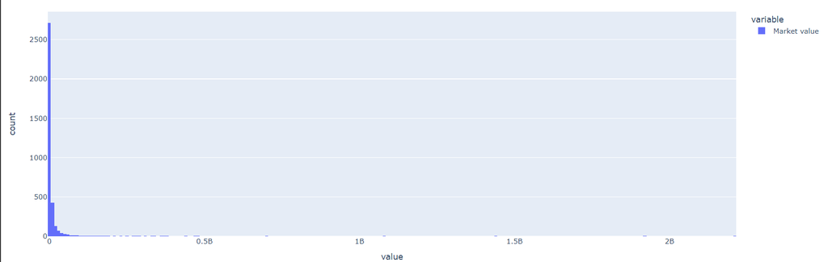

```python
px.histogram(df_ly['Book value'])
```

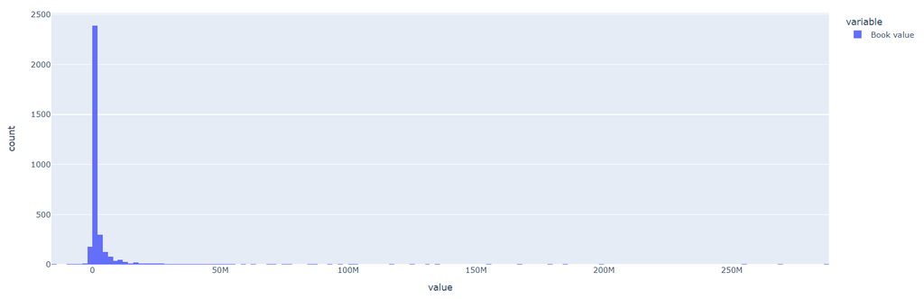

DE IGUAL MANERA QUE EN EL MARKET VALUE, AQUI SE PUEDE OBSERVAR QUE LA TENDENCIA ESTA MAS CERCA DEL LADO IZQUIERDO QUE EN EL CENTRO.

**Meidana de market value**

```python
df_ly['Market value'].median()
```

```
1105075.91083
```

**Meidana de book value**

```python
df_ly['Book value'].median()
```

```
457737.0
```

PARA PODER HACER UNA PREDICCIÓN SOBRE LAS VENTAS DE ALGUNA INDUSTRIA TENEMOS QUE SABER CUÁLES SON AQUELLAS VARIABLES QUE AFECTAN MAS A ESE VALOR.

```python
df_corrs = df_mrg.corr()["revenue"]
df_corrs.sort_values(ascending=False)
```

```
revenue                    1.000000
cogs                       0.931408
sgae                       0.677615
Operating profit margin    0.641803
Market value               0.615881
stockholderequity          0.595631
Book value                 0.595626
Ebit                       0.589684
sharesoutstanding          0.494759
Net income                 0.487594
incometax                  0.449182
finexp                     0.379055
longdebt                   0.378894
otheropexp                 0.333943
totalassets                0.323492
shortdebt                  0.291061
totalliabilities           0.275417
originalprice              0.151463
r                          0.030197
r2                         0.030197
Profit margin              0.005425
OPM                        0.005302
fiscalmonth                0.003523
adjprice                  -0.002771
lprice                    -0.002971
extraincome               -0.025453
Name: revenue, dtype: float64
```

SE PUEDE OBSERVAR QUE LAS QUE TIENEN UNA MAYOR RELACIÓN SON:

- cogs (Cost of good sold )
- sgae (sales and general administrative expenses)
- market value

NO SELECCIONO "OPERATING PROFIT" DEBIDO A QUE PARA SU CALCULO YA SE USA "REVENUE", PROVOCANDO ASI QUE SE VUELVA UNA VARIABLE DEPENDIENTE.

# Análisis por industria

ELIMINACIÓN DE COLUMNAS INNECESARIAS PARA ESTE ANÁLISIS

```python
df_ind = df_ly.drop(["revenue","cogs","sgae","Operating profit margin","stockholderequity","Ebit","sharesoutstanding","Net income","incometax","finexp","longdebt","otheropexp","totalassets","shortdebt","totalliabilities","originalprice","r","r2","OPM","fiscalmonth","adjprice","lprice","extraincome","Sector\nEconomatica","q","qdate","Name","firm","Profit margin"], axis=1)
```

```python
df_ind
```

|  | Sector NAICS\nlevel 1 | Book value | Market value |
| --- | --- | --- | --- |
| 89 | Retail Trade | NaN | 6.139275e+05 |
| 179 | Manufacturing | 783516.000 | 5.130081e+06 |
| 269 | Retail Trade | NaN | 1.297925e+05 |
| 359 | Health Care and Social Assistance | 1624482.000 | 1.521332e+06 |
| 449 | Finance and Insurance | 910667.000 | 1.122858e+06 |
| ... | ... | ... | ... |
| 323455 | Information | 188856.000 | 1.156340e+06 |
| 323545 | Manufacturing | 229400.000 | 3.431356e+06 |
| 323635 | Professional, Scientific, and Technical Services | 236623.000 | 1.268631e+05 |
| 323725 | Manufacturing | 57241.873 | 4.969939e+04 |
| 323815 | Information | NaN | 9.302899e+06 |

3600 rows × 3 columns

```python
print("Pormedio de valor de libro")
print(df_ind['Book value'].mean())
print("Mediana de valores de libro")
print(df_ind['Book value'].median())
```

```
Pormedio de valor de libro
3331748.585335812
Mediana de valores de libro
457737.0
```

```python
print("Pormedio de valor de mercado")
print(df_ind['Market value'].mean())
print("Mediana de valores de mercado")
print(df_ind['Market value'].median())
```

```
Pormedio de valor de mercado
10959802.487230346
Mediana de valores de mercado
1105075.91083
```

RECORDEMOS QUE PARA TENER UN VALOR MAS ACERTADO SOBRE EL VALOR COMÚN DE UNA FIRMA TENEMOS QUE TOMAR LA MEDIANA.

Creación de columnas suma

```python
df_ind_sum = df_ind.groupby("Sector NAICS\nlevel 1").sum()
df_ind_sum.columns = df_ind_sum.columns.str.replace('Book value', 'Book value sum')
df_ind_sum.columns = df_ind_sum.columns.str.replace('Market value', 'Market value sum')
```

Creación de columnas media

```python
df_ind_mean = df_ind.groupby("Sector NAICS\nlevel 1").mean()
df_ind_mean.columns = df_ind_mean.columns.str.replace('Book value', 'Book value mean')
df_ind_mean.columns = df_ind_mean.columns.str.replace('Market value', 'Market value mean')
```

Creación de columnas mediana

```python
df_ind_median = df_ind.groupby("Sector NAICS\nlevel 1").median()
df_ind_median.columns = df_ind_median.columns.str.replace('Book value', 'Book value median')
df_ind_median.columns = df_ind_median.columns.str.replace('Market value', 'Market value median')
```

Creación de columnas desviación estándar

```python
df_ind_std = df_ind.groupby("Sector NAICS\nlevel 1").std()
df_ind_std.columns = df_ind_std.columns.str.replace('Book value', 'Book value std')
df_ind_std.columns = df_ind_std.columns.str.replace('Market value', 'Market value std')
```

Integración de las columnas en un dataframe

```python
df_ind = pd.merge(df_ind_sum, df_ind_mean,  on="Sector NAICS\nlevel 1")
df_ind = pd.merge(df_ind, df_ind_median,  on="Sector NAICS\nlevel 1")
df_ind = pd.merge(df_ind, df_ind_std,  on="Sector NAICS\nlevel 1")
```

Creación de columna de numero de firmas por industria

```python
df_ind["#firms"] = df_ly['Sector NAICS\nlevel 1'].value_counts()
```

**Mover valor de by para ordenar según la necesidad del dato que se quina analizar**

```python
df_ind.sort_values(by='Book value std', ascending=False)
```

| Sector NAICS level 1 | Book value sum | Market value sum | Book value mean | Market value mean | Book value median | Market value median | Book value std | Market value std | #firms |
| --- | --- | --- | --- | --- | --- | --- | --- | --- | --- |
| Professional, Scientific, and Technical Services | 5.028128e+08 | 2.498370e+09 | 3.566048e+06 | 1.723014e+07 | 279188.000 | 9.419611e+05 | 2.386749e+07 | 1.241168e+08 | 145 |
| Arts, Entertainment, and Recreation | 1.024938e+08 | 2.684345e+08 | 5.394410e+06 | 1.278260e+07 | 67242.769 | 2.504698e+06 | 2.206931e+07 | 3.685083e+07 | 21 |
| Finance and Insurance | 3.635015e+09 | 5.804471e+09 | 5.482677e+06 | 8.412277e+06 | 1049158.000 | 1.264517e+06 | 2.071494e+07 | 2.920083e+07 | 701 |
| Information | 1.036435e+09 | 5.006711e+09 | 4.213150e+06 | 1.918280e+07 | 500953.500 | 2.586582e+06 | 1.720145e+07 | 1.221314e+08 | 261 |
| Retail Trade | 5.002175e+08 | 3.038192e+09 | 3.379848e+06 | 1.998810e+07 | 577426.500 | 1.444971e+06 | 1.445068e+07 | 9.621283e+07 | 152 |
| Utilities | 5.432704e+08 | 1.222991e+09 | 7.148295e+06 | 1.588301e+07 | 2791950.000 | 6.040649e+06 | 9.936777e+06 | 2.346024e+07 | 77 |
| Manufacturing | 3.449484e+09 | 1.591143e+10 | 2.417298e+06 | 1.040643e+07 | 244642.000 | 5.911289e+05 | 9.898371e+06 | 6.766673e+07 | 1565 |
| Administrative and Support and Waste Management and Remediation Services | 3.496151e+08 | 1.815095e+09 | 2.819477e+06 | 1.385569e+07 | 566167.000 | 1.938284e+06 | 7.323975e+06 | 4.476903e+07 | 133 |
| Agriculture, Forestry, Fishing and Hunting | 5.444340e+07 | 1.287485e+08 | 3.629560e+06 | 8.046780e+06 | 1104345.000 | 1.264045e+06 | 6.806214e+06 | 1.457197e+07 | 16 |
| Transportation and Warehousing | 2.334237e+08 | 8.100485e+08 | 3.536723e+06 | 1.191248e+07 | 1288121.500 | 2.464494e+06 | 6.139909e+06 | 2.734213e+07 | 69 |
| Mining, Quarrying, and Oil and Gas Extraction | 3.245564e+08 | 6.986798e+08 | 3.345942e+06 | 6.783299e+06 | 741145.000 | 1.042405e+06 | 5.905346e+06 | 1.362354e+07 | 103 |
| Construction | 1.115629e+08 | 1.735840e+08 | 2.535521e+06 | 3.857422e+06 | 998146.500 | 1.745045e+06 | 4.271095e+06 | 5.646435e+06 | 45 |
| Real Estate and Rental and Leasing | 1.180439e+08 | 2.465160e+08 | 1.816059e+06 | 3.625235e+06 | 634398.000 | 8.819927e+05 | 3.074362e+06 | 1.020873e+07 | 68 |
| Wholesale Trade | 1.147446e+08 | 3.848500e+08 | 1.529928e+06 | 4.871519e+06 | 683900.000 | 1.424602e+06 | 2.905938e+06 | 8.715762e+06 | 79 |
| Accommodation and Food Services | 3.494665e+07 | 5.989938e+08 | 5.139213e+05 | 8.681070e+06 | 243717.500 | 1.394617e+06 | 2.456108e+06 | 2.507255e+07 | 69 |
| Health Care and Social Assistance | 6.372857e+07 | 2.209870e+08 | 1.080145e+06 | 3.507730e+06 | 451385.000 | 1.338427e+06 | 1.919774e+06 | 7.028577e+06 | 64 |
| Educational Services | 1.250447e+07 | 1.823613e+07 | 8.931767e+05 | 1.302581e+06 | 649699.000 | 1.524843e+06 | 1.110081e+06 | 1.039264e+06 | 14 |
| Other Services (except Public Administration) | 8.336221e+06 | 3.417850e+07 | 5.954443e+05 | 2.136156e+06 | 431667.000 | 8.540956e+05 | 7.305512e+05 | 2.941800e+06 | 16 |
| - | 5.704446e+06 | 4.865183e+06 | 5.704446e+06 | 4.865183e+06 | 5704446.000 | 4.865183e+06 | NaN | NaN | 2 |

**Analiísis por suma**

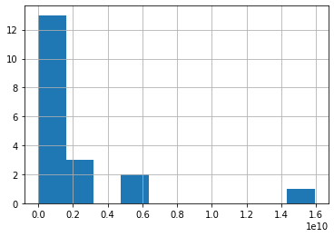

```python
df_ind['Market value sum'].hist()
```

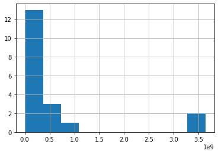

```python
df_ind['Book value sum'].hist()
```

COMO SE PUEDE OBSERVAR EN AMBOS HISTOGRAMAS, LA MAYORÍA DE LAS INDUSTRIAS TIENEN UN VALOR NO MAYOR A LOS MIL BILLONES DE DOLARES, SON ENTRE 3 Y 4 INDUSTRIAS LAS QUE SOBRESALEN, ESTO SE DEBE A QUE ESTAS SON LAS QUE TIENEN MAYOR PRECENCIA EN EL MERCADO HABLANDO DE CANTIDAD DE FIRMAS POR INDUSTRIA.

LA INDUSTRIA CON UNA MAYOR SUMA DE VALOR DE LIBRO ES LA DE FINANZAS MIENTRAS QUE EN EL VALOR DE MERCADO ES LA INDUSTRIA DE MANUFACTURA. AQUÍ SE PUEDE OBSERVAR ALGO EXTRAÑO PORQUE A PESAR DE QUE MANUFACTURA TIENE MÁS FIRMAS NO LLEGA TENER LA SUMA MÁS GRANDE EN AMBAS METRICAS.

**Analiísis por media**

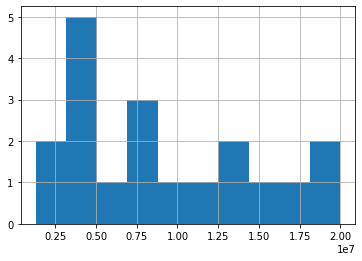

```python
df_ind['Market value mean'].hist()
```

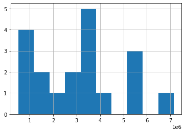

```python
df_ind['Book value mean'].hist()
```

LA INDUSTRIA QUE TIENE UN PROMEDIO MÁS ALTO DE VALOR DE LIBRO ES LA DE "UTILITIES", MIENTRAS QUE EN EL VALOR DE MERCADO ES LA INDUSTRIA DE "RETAIL TRADE".

**Analiísis por mediana**

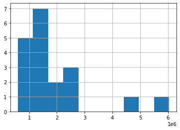

```python
df_ind['Market value median'].hist()
```

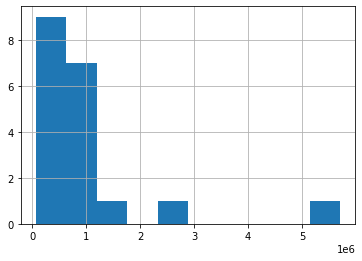

```python
df_ind['Book value median'].hist()
```

EN ESTOS HISTOGRAMAS A DIFERENCIA DE LOS ANTERIORES SE PUEDE VER QUE LAS MEDIANA PRINCIPALMENTE SE ENCUENTRAN MÁS CERCANAS AL ORIGEN, ESTO SE DEBE A QUE COMO HEMOS VISTO LA MAYORIA DE LAS EMPRESAS CON VALORES MÁS ALTOS PERTENENCEN A INDUSTRIAS EN ESPECÍFICO, PROVOCANDO ASI QUE SUS RESPECTIVAS MEDIANAS ESTEN SEPARADAS DEL RESTO.

ESTE VALOR ES EL SIGNIFICATIVO COMO VIMOS ANTERIORMENTE, ASI QUE ESTAS EMPRESAS SON LAS QUE NORMALMENTE TIENEN UN MAYOR VALOR. EN ESTE CASO LA INDUSTRIA QUE SE ENCUENTRA POR ENCIMA EN AMBOS VALORES ES LA DE "UTILITIES"

**Análisis por std**

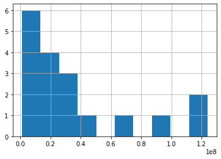

```python
df_ind['Market value std'].hist()
```

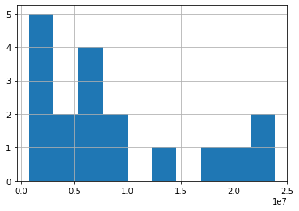

```python
df_ind['Book value std'].hist()
```

DENTRO DE ESTOS GRÁFICOS PODEMO VER QUE LAS DESVIACIONES ESTÁNDAR LLEGAN A SER CANTIDADES MÁS GRANDES, ESTO SE PUEDE DEBER A QUE QUE EN CIERTAS INDUSTRIAS TIENEN SUS VALORES MUY DESPEGADOS UNOS DE OTROS, PROVOCANDO ASI QUE SU DESVIACIÓN ESTÁNDAR SEA MAS GRANDE COMO ES EL CASO DE "PROFESSIONAL, SCIENTIFIC, AND TECHNICAL SERVICES" QUE ES LA INDUSTRIA QUE SU DESVIACIÓN ESTÁNDAR EN SU VALOR DE MERCADO ES LA MÁS GRANDE.

Con esta varaibale podemos ver que industria es la que mas varia en sus valores, "Professional, Scientific, and Technical Services" es la que mas fluctua tanto en su valor de mercado como de libro.

# Análisis de 3 empresas

```python
df_ly["Book value"].median()
```

```
457737.0
```

```python
order = df_ly.sort_values(by=["Book value"])
```

```python
order.iloc[1800]
```

```
firm                                INVA
Name                       Innoviva, Inc
Sector NAICS\nlevel 1      Manufacturing
Sector\nEconomatica             Chemical
q                                 2022q2
revenue                         108220.0
cogs                                 0.0
sgae                             25666.0
otheropexp                           0.0
extraincome                     -79560.0
finexp                            2931.0
incometax                         -876.0
totalassets                    1137639.0
totalliabilities                572177.0
shortdebt                       100570.0
longdebt                        443178.0
stockholderequity               565462.0
adjprice                           14.76
originalprice                      14.76
sharesoutstanding              69698.562
fiscalmonth                          6.0
Book value                      565462.0
Market value               1028750.77512
Operating profit margin          82554.0
Ebit                             82554.0
OPM                             0.762835
Net income                       80499.0
Profit margin                   0.743846
qdate                             2022Q2
lprice                             13.41
r                                0.09592
r2                               0.09592
Name: 151275, dtype: object
```

```python
df_ly[(df_ly['Book value']==3974240.0) | (df_ly['Book value']==565462.0) | (df_ly['Book value']==122844.0)]
```

|  | firm | Name | Sector NAICS\nlevel 1 | Sector\nEconomatica | q | revenue | cogs | sgae | otheropexp | extraincome | ... | Market value | Operating profit margin | Ebit | OPM | Net income | Profit margin | qdate | lprice | r | r2 |
| --- | --- | --- | --- | --- | --- | --- | --- | --- | --- | --- | --- | --- | --- | --- | --- | --- | --- | --- | --- | --- | --- |
| 9086 | ADC | Agree Realty Corp | Finance and Insurance | Funds | 2022q2 | 104876.0 | 0.0 | 52528.0 | 8.0 | -157.0 | ... | 5.422333e+06 | 52348.0 | 52340.0 | 0.499066 | 36130.0 | 0.344502 | 2022Q2 | 67.567880 | 0.062310 | 0.062310 |
| 57870 | CSV | Carriage Services, Inc | Other Services (except Public Administration) | Other | 2022q2 | 90600.0 | 62888.0 | 9180.0 | -1193.0 | 1383.0 | ... | 5.903510e+05 | 18532.0 | 19725.0 | 0.217715 | 9516.0 | 0.105033 | 2022Q2 | 36.479931 | 0.080038 | 0.080038 |
| 151275 | INVA | Innoviva, Inc | Manufacturing | Chemical | 2022q2 | 108220.0 | 0.0 | 25666.0 | 0.0 | -79560.0 | ... | 1.028751e+06 | 82554.0 | 82554.0 | 0.762835 | 80499.0 | 0.743846 | 2022Q2 | 13.410000 | 0.095920 | 0.095920 |

3 rows × 32 columns

```python
df_3firms = df_mrg[(df_mrg['Name']=="Innoviva, Inc") | (df_mrg['Name']=="Agree Realty Corp") | (df_mrg['Name']=="Carriage Services, Inc")]
```

```python
df_3firms
```

|  | firm | Name | Sector NAICS\nlevel 1 | Sector\nEconomatica | q | revenue | cogs | sgae | otheropexp | extraincome | ... | Market value | Operating profit margin | Ebit | OPM | Net income | Profit margin | qdate | lprice | r | r2 |
| --- | --- | --- | --- | --- | --- | --- | --- | --- | --- | --- | --- | --- | --- | --- | --- | --- | --- | --- | --- | --- | --- |
| 8997 | ADC | Agree Realty Corp | Finance and Insurance | Funds | 2000q1 | NaN | NaN | NaN | NaN | NaN | ... | NaN | NaN | NaN | NaN | NaN | NaN | 2000Q1 | NaN | NaN | NaN |
| 8998 | ADC | Agree Realty Corp | Finance and Insurance | Funds | 2000q2 | NaN | NaN | NaN | NaN | NaN | ... | NaN | NaN | NaN | NaN | NaN | NaN | 2000Q2 | NaN | NaN | NaN |
| 8999 | ADC | Agree Realty Corp | Finance and Insurance | Funds | 2000q3 | NaN | NaN | NaN | NaN | NaN | ... | NaN | NaN | NaN | NaN | NaN | NaN | 2000Q3 | NaN | NaN | NaN |
| 9000 | ADC | Agree Realty Corp | Finance and Insurance | Funds | 2000q4 | NaN | NaN | NaN | NaN | NaN | ... | NaN | NaN | NaN | NaN | NaN | NaN | 2000Q4 | NaN | NaN | NaN |
| 9001 | ADC | Agree Realty Corp | Finance and Insurance | Funds | 2001q1 | NaN | NaN | NaN | NaN | NaN | ... | NaN | NaN | NaN | NaN | NaN | NaN | 2001Q1 | NaN | NaN | NaN |
| ... | ... | ... | ... | ... | ... | ... | ... | ... | ... | ... | ... | ... | ... | ... | ... | ... | ... | ... | ... | ... | ... |
| 151271 | INVA | Innoviva, Inc | Manufacturing | Chemical | 2021q2 | 100806.0 | 0.0 | 4266.0 | 0.0 | 22466.0 | ... | 1.359881e+06 | 96540.0 | 96540.0 | 0.957681 | 66482.0 | 0.659504 | 2021Q2 | 13.98 | -0.041627 | -0.041627 |
| 151272 | INVA | Innoviva, Inc | Manufacturing | Chemical | 2021q3 | 97862.0 | 0.0 | 3309.0 | 0.0 | 2753.0 | ... | 1.161254e+06 | 94553.0 | 94553.0 | 0.966187 | 69685.0 | 0.712074 | 2021Q3 | 10.45 | 0.469405 | 0.469405 |
| 151273 | INVA | Innoviva, Inc | Manufacturing | Chemical | 2021q4 | 107680.0 | 0.0 | 3153.0 | 0.0 | -79838.0 | ... | 1.198740e+06 | 104527.0 | 104527.0 | 0.970719 | 90183.0 | 0.837509 | 2021Q4 | 12.39 | 0.330922 | 0.330922 |
| 151274 | INVA | Innoviva, Inc | Manufacturing | Chemical | 2022q1 | 90059.0 | 0.0 | 12330.0 | 0.0 | -52408.0 | ... | 1.346092e+06 | 77729.0 | 77729.0 | 0.863090 | 68181.0 | 0.757070 | 2022Q1 | 11.95 | 0.481961 | 0.481961 |
| 151275 | INVA | Innoviva, Inc | Manufacturing | Chemical | 2022q2 | 108220.0 | 0.0 | 25666.0 | 0.0 | -79560.0 | ... | 1.028751e+06 | 82554.0 | 82554.0 | 0.762835 | 80499.0 | 0.743846 | 2022Q2 | 13.41 | 0.095920 | 0.095920 |

270 rows × 32 columns

```python
px.line(df_3firms, x = 'q', y = 'Book value', color = 'Name')
```

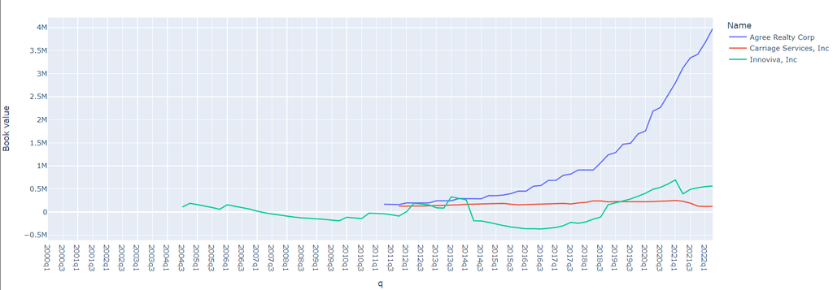

```python
px.line(df_3firms, x = 'q', y = 'Market value', color = 'Name')
```

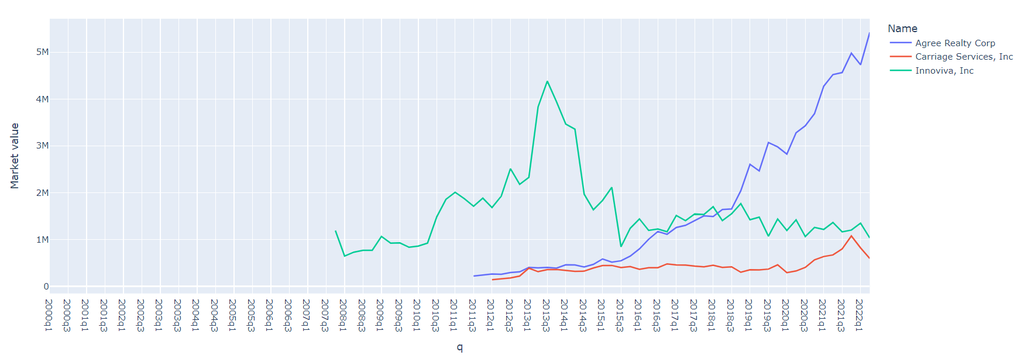

EN AMBAS GRÁFICAS SE PUEDEN APRECIAR LOS DISTINTOS COMPORTAMIENTOS DEPENDIENDO DEL TAMAÑO DE LA EMPRESA

```python
df_corrs = df_3firms.corr()["Book value"]
df_corrs.sort_values(ascending=False)
```

```
Book value                 1.000000
stockholderequity          1.000000
totalassets                0.968991
lprice                     0.862300
adjprice                   0.829957
longdebt                   0.805276
originalprice              0.800069
totalliabilities           0.695946
Market value               0.687064
finexp                     0.436418
revenue                    0.378518
Ebit                       0.323749
sgae                       0.318301
Operating profit margin    0.317595
Net income                 0.243141
shortdebt                  0.171917
Profit margin              0.046055
OPM                        0.043243
r                          0.028386
r2                         0.028386
incometax                  0.027242
extraincome                0.026291
fiscalmonth               -0.022573
sharesoutstanding         -0.094339
cogs                      -0.150380
otheropexp                -0.172050
Name: Book value, dtype: float64
```

```python
df_corrs = df_3firms.corr()["Market value"]
df_corrs.sort_values(ascending=False)
```

```
Market value               1.000000
sgae                       0.743106
longdebt                   0.713742
stockholderequity          0.687064
Book value                 0.687064
totalassets                0.686717
lprice                     0.656082
adjprice                   0.630590
originalprice              0.609918
totalliabilities           0.541906
sharesoutstanding          0.526470
finexp                     0.480460
Ebit                       0.056906
Operating profit margin    0.047988
revenue                    0.045512
Net income                 0.025745
extraincome                0.001116
fiscalmonth               -0.011029
r                         -0.020550
r2                        -0.020550
incometax                 -0.054377
shortdebt                 -0.065261
otheropexp                -0.208814
OPM                       -0.251646
Profit margin             -0.258395
cogs                      -0.465615
Name: Market value, dtype: float64
```

LO QUE PODEMOS OBSERVAR ES QUE LA CANTIDAD DE INVERSIÓN SOBRE LA EMPRESA, SU TOTAL DE ASSETS SON FACTORES QUE ESTAN MUY RELACIONADOS CON EL CRECIMIENTO DEL TAMÑAO DE LA EMPRESA. ESTAS VARIABLES SON LAS QUE MAS RELACIÓN TIENEN EN CONTRA LA VARIABLE DEPENDIENTE.

# Etapa 2

# Posibles variables independientes

```python
df_reg["EPS"] = df_reg['Net income'] / df_reg["sharesoutstanding"]
```

```python
df_reg["EPSP"] = (df_reg['EPS'] / df_reg["originalprice"])
```

```python
df_reg["Sales anual growht"] = (df_reg['revenue'] / df_reg.groupby(["firm"])["revenue"].shift(4)) - 1
```

```python
df_reg["Operating profit growht"] = (df_reg['Ebit'] / df_reg.groupby(["firm"])["Ebit"].shift(4)) - 1
```

```python
df_reg["Operating profit margin"] = df_reg['Ebit'] / df_reg['revenue']
```

```python
df_reg['Book to market ratio'] = df_reg['Book value'] / df_reg['Market value']
```

```python
df_reg['Short financial leverage'] = df_reg['shortdebt'] / df_reg['totalassets']
```

```python
df_reg['Long financial leverage'] = df_reg['longdebt'] / df_reg['totalassets']
```

```python
df_reg["Stock annual return"] = np.log(df_reg['adjprice']) - np.log(df_reg.groupby(["firm"])['adjprice'].shift(4))
```

```python
df_reg["F1r"] = df_reg.groupby(["firm"])['Stock annual return'].shift(-1)
```

```python
df_reg = df_reg.replace([np.nan], 0)
```

```python
df_reg.replace([np.inf, -np.inf], np.nan, inplace=True)
```

CREACIÓN DE LAS VARIABLES DE SIZE

```python
def dense_inclusive_pct(x):
    r = x.rank(method='dense') - 1
    return r / r.max() * 100

df_reg["pct"]=df_reg.groupby('q')['Market value'].apply(dense_inclusive_pct).astype(int)


df_reg["isSmall"] = df_reg.pct <= 33
df_reg["isSmall"] = df_reg["isSmall"].astype(int)

df_reg["isMedium"] = (df_reg.pct <= 66) & (df_reg.pct > 33)
df_reg["isMedium"] = df_reg["isMedium"].astype(int)
```

FILTRAR DF PARA SOLO TENER LAS EMPRESAS DE MANUFACTURA

```python
is_man=df_reg[df_reg["Sector NAICS\nlevel 1"]!="Manufacturing"].index
df_reg=df_reg.drop(is_man)
```

GRÁFICO DEL STOCK ANNUAL RETURN POR FIRMA QUE PERTENECEN A LA INDUSTRIA DE MANUFACTURA

```python
px.line(df_reg, x = 'q', y = 'Stock annual return', color = 'firm')
```

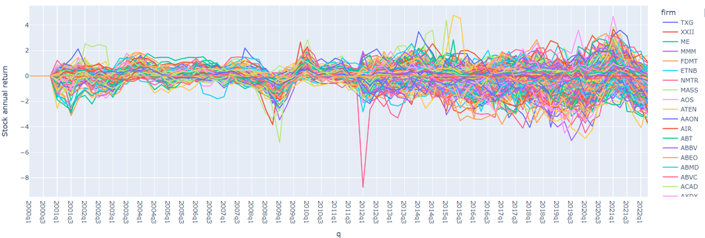

SE PUEDE OBSERVAR QUE EN 2009 COMO EN 2019 SE PRESENTARON FENOMENOS QUE LLEVARON UNA GRAN CATIDAD DE EMPRESAS A LA BAJA, ESTO PUEDE SER UN FENÓMENO INTERESANTE DE ANALIZAR.

POSIBLES VARIABLES QUE UTILIZAREMOS PARA EL MODELO DE PREDICCIÓN

```python
df_regL = df_reg.loc[:, ["firm","q","Stock annual return", "F1r","EPSP", "Sales anual growht", "Operating profit growht", "Operating profit margin", 'Book to market ratio', 'Short financial leverage', 'Long financial leverage', 'isSmall', 'isMedium']]
```

```python
df_corrs = df_regL.corr()["Stock annual return"]
df_corrs.sort_values(ascending=False)
```

```
Stock annual return         1.000000
F1r                         0.695838
isMedium                    0.100521
Operating profit margin     0.005460
Operating profit growht     0.003944
Sales anual growht          0.001824
Book to market ratio        0.000019
EPSP                        0.000017
Long financial leverage    -0.000229
Short financial leverage   -0.001970
isSmall                    -0.181240
Name: Stock annual return, dtype: float64
```

```python
from scipy.stats.mstats import winsorize
```

# Creación del modelo

```python
import seaborn as sns
import matplotlib.pyplot as plt
from sklearn.linear_model import LinearRegression
from sklearn.metrics import mean_squared_error
from scipy import stats
import statsmodels.api as sm
```

```python
df_train = df_regL.copy()
```

```python
df_train = df_train.replace([np.nan], 0)
```

```python
df_train.replace([np.inf, -np.inf], np.nan, inplace=True)
```

```python
df_vals = df_train[["EPSP","Operating profit growht","Short financial leverage","Sales anual growht", 'isSmall', 'isMedium']]
```

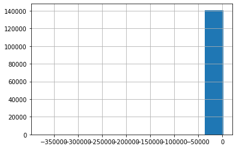

```python
df_vals["EPSP"].hist()
```

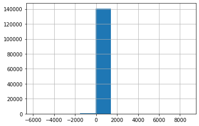

```python
df_vals["Operating profit growht"].hist()
```

SE PUEDE VER QUE ESTE HISTOGRAMA ESTA MÁS CENTRADO PERO UN POCO LADEADO A LA IZQUIERDA, ESTO NOS DICE QUE DEBEMOS DE WINSORIZAR MAYORMENTE DE LIMITE SUPERIOR Y POCO EN EL INFERIOR

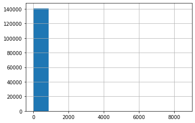

```python
df_vals["Short financial leverage"].hist()
```

SE PUEDE OBSERVAR QUE SUS VALORES QUE MAYOR CANTIDAD DE VECES SE REPITEN SON LOS DEL MARGEN IZQUIERDO, ESTO SIGNIFICA QUE WINSORIZAREMOS MÁS DEL LÍMITE SUPERIOR.

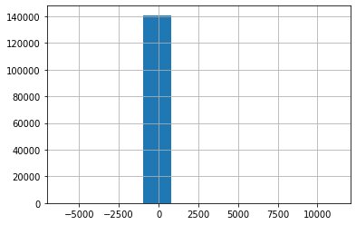

```python
df_vals["Sales anual growht"].hist()
```

ESTE ES EL CASO MÁS CENTRAL, POR ENDE LA WINSORIZACIÓN SE REPARTIRA CASÍ DE MANERA EQUITATIVA DE AMBOS LADOS DANDO EL MAYOR VALOR AL LIMITE SUPERIOR.

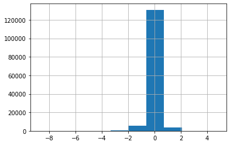

```python
df_train["F1r"].hist()
```

ESTE ES EL CASO EN DONDE SE ENCUENTRA UNA MAYOR DISTRIBUCIÓN NORMAL, ASI QUE WINSORIZAREMOS CASI IGUAL DE AMBOS LADOS.

```python
df_vals["EPSP"] = winsorize(df_vals["EPSP"], limits=[0.00018, 0.00002])
df_vals["Operating profit growht"] = winsorize(df_vals["Operating profit growht"], limits=[0.005, 0.015])
df_vals["Short financial leverage"] = winsorize(df_vals["Short financial leverage"], limits=[0.002,0.018])
df_vals["Sales anual growht"] = winsorize(df_vals["Sales anual growht"], limits=[0.008,0.012])
df_train["F1r"] = winsorize(df_train["F1r"], limits=[0.0013,0.007])
```

```python
df_vals
```

|  | EPSP | Operating profit growht | Short financial leverage | Sales anual growht | isSmall | isMedium |
| --- | --- | --- | --- | --- | --- | --- |
| 90 | 0.000000 | 0.000000 | 0.000000 | 0.0 | 1 | 0 |
| 91 | 0.000000 | 0.000000 | 0.000000 | 0.0 | 1 | 0 |
| 92 | 0.000000 | 0.000000 | 0.000000 | 0.0 | 1 | 0 |
| 93 | 0.000000 | 0.000000 | 0.000000 | 0.0 | 1 | 0 |
| 94 | 0.000000 | 0.000000 | 0.000000 | 0.0 | 1 | 0 |
| ... | ... | ... | ... | ... | ... | ... |
| 323721 | -0.045058 | -0.549558 | 0.002100 | 0.0 | 1 | 0 |
| 323722 | -0.058349 | 0.106033 | 0.002307 | 0.0 | 1 | 0 |
| 323723 | -0.074402 | -0.132792 | 0.002576 | 0.0 | 1 | 0 |
| 323724 | -0.101221 | 0.129250 | 0.002830 | 0.0 | 1 | 0 |
| 323725 | -0.182640 | -0.068072 | 0.003163 | 0.0 | 1 | 0 |

140841 rows × 6 columns

**Comportamiento de las variables después de la winsorización**

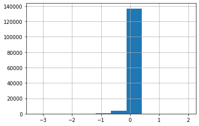

```python
df_vals["EPSP"].hist()
```

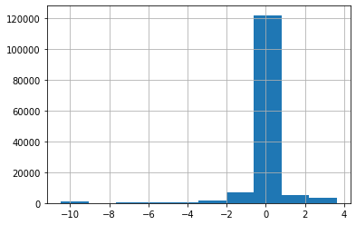

```python
df_vals["Operating profit growht"].hist()
```

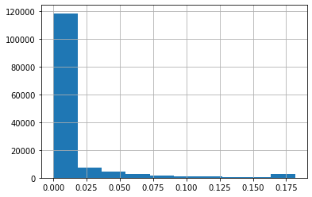

```python
df_vals["Short financial leverage"].hist()
```

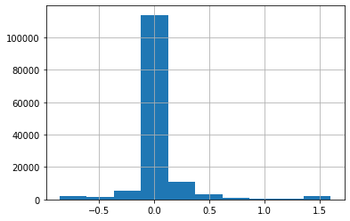

```python
df_vals["Sales anual growht"].hist()
```

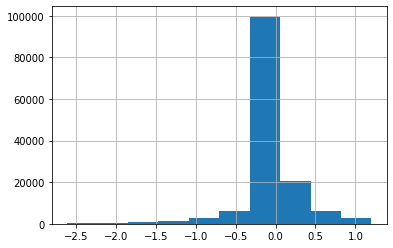

```python
df_train["F1r"].hist()
```

SE PUEDE OBSERVAR QUE TODOS LOS GRÁFICOS HAN CAMBIADO, MÁS CERCANOS A UN COMPORTAMIENTO NORMAL, SE PODRÍA HACER UNA MAYOR WISORIZACIÓN, PERO ESTO NO ES RECOMENDABLE DEBIDO A QUE SE COMENZARIA A CAMBIAR MUCHA INFORMACIÓN REAL POR INFORMACIÓN EQUIVOCA, SIENDO ESTO PERJUDICIAL PARA LAS PREDICCIONES DEL MODELO EN UN AMBIENTE REAL.

**Multicoliedalidad**

SE HACE UN ANÁLISIS DE MULTICOLINEALIDAD PARA VER SI ENTRE ALGUNAS DE LAS VARIABLES HAY UNA REALCCIÓN MUY ESTRECHA

```python
from statsmodels.stats.outliers_influence import variance_inflation_factor
vif_data = pd.DataFrame()
vif_data["feature"] = df_vals.columns

# calculating VIF for each feature
vif_data["VIF"] = [variance_inflation_factor(df_vals.values, i)
                          for i in range(len(df_vals.columns))]

print(vif_data)
```

```
                    feature       VIF
0                      EPSP  1.038572
1   Operating profit growht  1.004987
2  Short financial leverage  1.108172
3        Sales anual growht  1.034471
4                   isSmall  1.055615
5                  isMedium  1.070410
```

SE PUEDE OBSERVAR QUE ENTRE NUNGANA DE LAS VARIABLES EXISTE MULTICOLINEALIDAD, ESTO SE DEFINE PORQUE NINGUNA DE ELLAS ES MAYOR A 10, EN REALIDAD SU VALOR ES MUY BAJO CASI 1, SIENTO ESTE EL VALOR MAS BAJO.

# Entrenamiento del modelo

```python
X = df_vals
Y = df_train["F1r"]
```

```python
reg = LinearRegression()
reg = reg.fit(X,Y)
Y_pred = reg.predict(X)
```

**Resultados del modelo**

Mean Squared Error

```python
MSE = (mean_squared_error(Y,Y_pred))
MSE
```

```
0.11476505489772384
```

R2

```python
r2 = reg.score(X,Y)
r2
```

```
0.13343613314655034
```

Coeficientes

```python
reg.coef_
```

```
array([ 1.18511115,  0.00689472, -0.55764535,  0.11294936, -0.12656989,
       -0.03846789])
```

```python
X2 = sm.add_constant(X)
est = sm.OLS(Y,X2)
est2 = est.fit()
print(est2.summary())
```

```
                            OLS Regression Results
==============================================================================
Dep. Variable:                    F1r   R-squared:                       0.133
Model:                            OLS   Adj. R-squared:                  0.133
Method:                 Least Squares   F-statistic:                     3614.
Date:                Tue, 13 Sep 2022   Prob (F-statistic):               0.00
Time:                        20:38:25   Log-Likelihood:                -47394.
No. Observations:              140841   AIC:                         9.480e+04
Df Residuals:                  140834   BIC:                         9.487e+04
Df Model:                           6
Covariance Type:            nonrobust
============================================================================================
                               coef    std err          t      P>|t|      [0.025      0.975]
--------------------------------------------------------------------------------------------
const                        0.1081      0.003     39.970      0.000       0.103       0.113
EPSP                         1.1851      0.010    120.966      0.000       1.166       1.204
Operating profit growht      0.0069      0.001      9.065      0.000       0.005       0.008
Short financial leverage    -0.5576      0.028    -20.029      0.000      -0.612      -0.503
Sales anual growht           0.1129      0.003     32.408      0.000       0.106       0.120
isSmall                     -0.1266      0.003    -44.414      0.000      -0.132      -0.121
isMedium                    -0.0385      0.004    -10.917      0.000      -0.045      -0.032
==============================================================================
Omnibus:                    46492.390   Durbin-Watson:                   0.833
Prob(Omnibus):                  0.000   Jarque-Bera (JB):           910356.619
Skew:                          -1.102   Prob(JB):                         0.00
Kurtosis:                      15.259   Cond. No.                         39.6
==============================================================================

Notes:
[1] Standard Errors assume that the covariance matrix of the errors is correctly specified.
```

DESPUÉS DE TODAS LAS MODIFICACIONES DE LOS DATOS SE A LLEGADO A UN MODELO CON UN 13.3% DE CERTEZA, PROBABLEMENTE SE PODRÍA MEJORAR EL MODELO SI ES QUE USARÁN MAS VARIABLES O SE USARÁN METODOS DE PREDICCIÓN MAS ROBUSTOS, PERO ESTO NO NECESARIA SERÍA ASI, ESTO SE DEBE COMPLETAMENTE AL CONTEXTO, RECORDEMOS QUE ESTAMOS EN UN CONTEXTO DE PREDICCIONES FINANCIERAS, EN DONDE SI LOGRARAMOS PREDECIR EN GRAN MEDIDA LO QUE FUERA A SUCEDER, SE ROMPERÍA LA ECONOMIA Y VOLVERIAN A CAMBIAR LOS FACTORES DE PREDICCIÓN.

SE PUEDE OBSERVAR QUE TODAS LAS VARIABLES TIENEN UN T-VALUES MAYOR A 2, ESTO NOS DICE QUE LAS VARIABLES EXPLICAN MUY BIEN A LA DEPENDIENTE, SIENDO LA MÁS ALTA LA DEL EPSP, POR EL CONTRARIO LA MÁS BAJA ES LA DE "OPERATING PROFIT GROWTH". ESTO TAMBIEN SE PUEDE OBSERVAR CON EL P-VALUE EN DONDE TDOS ELLOS SON 0 Ó MUY CERCANOS A EL. RESULTA INTERESANTE, QUE APESAR DE QUE EPSP TIENE UNA MAYOR EXPLICACIÓN CUANDO VIMOS LAS CORRELACIONES ERA LA QUE CONTABA CON EL MENOR VALOR.

AQUELLAS VARIABLES QUE TIENEN UNA RELACIÓN POSITIVA CON RESPECTO A SU MAGNITUD SON "EPSP", "OPERATING PROFIT GROWTH" Y "SALES ANNUAL GROWT", CON VALORES DE 1.18, 0.0069 Y 0.1 RESPECTIVAMENTE. POR EL CONTRARIO, AQUELLAS QUE TIENEN UNA MAGNITUD NEGATIVA ES "SHORT FINANCIAL LEVERAGE" CON UN VALOR DE -0.55

EXISTEN TAMBIEN LAS MAGNITUDES DE LOS TAMAÑOS DE LA EMPRESA, PERO COMO ESTA VARIABLE ES BINARIA SOLAMENTE SE LE SUMARÁ AL INTERCEPTO, DANDONOS COMO RESULTADO 3 DISTINTOS MODELOS, UNO PARA CADA TAMAÑO DE EMPRESA.

```python
%%shell
jupyter nbconvert --to html /content/gdrive/MyDrive/IA/Estadistica/bcase.ipynb
```

```
[NbConvertApp] Converting notebook /content/gdrive/MyDrive/IA/Estadistica/bcase.ipynb to html
[NbConvertApp] Writing 1674392 bytes to /content/gdrive/MyDrive/IA/Estadistica/bcase.html
```